# Burden of Disease Report

Collaborative GitHub and RMarkdown Practice

The GRAPH Courses Team

# Introduction

In this workshop, you will work collaboratively in groups of 3 to create a report on the burden of disease for three countries of your choice. The goal is to practice collaborative coding using GitHub, and creating a modular R Markdown report.

## Report Structure

The example report is divided into 3 major subsections:

1. Communicable, Maternal, Neonatal, and Nutritional Disease Burden (CMNN)
2. Non-Communicable Disease Burden (NCD)
3. Overall Disease Burden

**We have created a minimal example of report [here](https://github.com/the-graph-courses/misc_public/blob/main/rmc_week_02_workshop/rmd/burden_of_disease_report.md).**

You and your group members will work together to do the analysis, and each group member will be responsible for one section of the report.

If you have only 2 group members, you will only have to complete the first two sections.

## Collaboration workflow

All group members will be pushing and pulling from the same GitHub repo.

[figure not shown]

As you may remember from the lesson, merge conflicts can happen when multiple collaborators are working on the same document.

To avoid merge conflicts, we will split the full report into shorter documents, and each member can work on their own document without disturbing the others.

1. **Partner 1 (Repo Owner)** - Section 1: CMNN burden
2. **Partner 2** - Section 2: NCD burden
3. **Partner 3** - Section 3: Overall burden

Each group member should take responsibility for completing one of these child documents.

Then, everyone will pull the changes from the repo and knit the main report.

# TASK 1: FORK ORIGINAL REPO (Partner 1)

Pick one group member to be the repo “owner” (Partner 1).

They should fork the template repository from here: https://github.com/the-graph-courses/rmc_week_02_workshop.

**NOTE**: Please choose someone who is able to screenshare. They should share while doing tasks 1 and 2, so that other group members understand how these work.

[figure not shown]

Partner 1 (Repo owner) should fork the repo from the TGC GitHub link above. Other group members should NOT do this step.

# TASK 2: ADD COLLABORATORS (Partner 1)

Now the repo owner will add the other group members as collaborators on the forked repo.

In the newly forked repo, Partner 1 should go to Settings > Collaborators > Add people

[figure not shown]

Then enter the username or email for Partner 2. Repeat the process for Partner 3.

## TASK 3: ACCEPT COLLABORATION INVITE (Partners 2 & 3)

Invitations will be pending until the other users accept the invitation. Partners 2 & 3 should check their email or GitHub notifications to accept the invite.

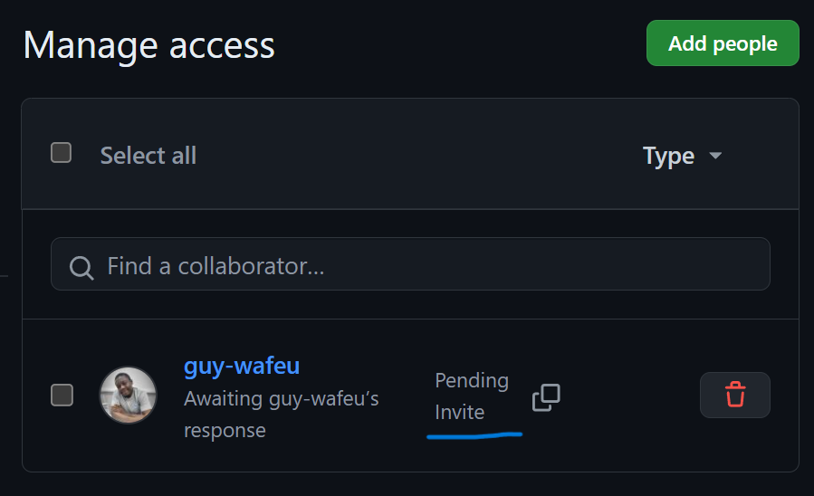

## TASK 4: CLONE REPO TO LOCAL COMPUTERS (Everyone)

All group members should then clone the repo to an appropriate location on their local machine.

[figure not shown]

# TASK 5: CHOOSE THREE COUNTRIES (Everyone)

As a group, decide on three countries you want to analyze and compare in your report. Make sure each group member knows which countries were selected. Most countries should be in the data, but a few may not be.

If you happen to pick a country that is not in the data, just choose another one.

# TASK 6: COMPLETE THE CHILD DOCUMENTS (Everyone)

The “rmd” folder of the repo contains a main RMarkdown file `daly_report_PARENT.Rmd` which includes three child documents:

1. `01_cmnn_burden_CHILD.Rmd`: This document will compare the DALY burden of communicable, maternal, neonatal, and nutritional diseases for the three countries.
2. `02_ncd_burden_CHILD.Rmd`: This document will compare the DALY burden of non-communicable diseases for the three countries.
3. `03_overall_burden_CHILD.Rmd`: This document will compare the overall DALY burden for the three countries.

If there are three group members, each person should complete one child document. If there are two group members, you should only complete the first two child documents.

Read the commented instructions in your assigned child document and fill in the code for each code chunk, analyzing the DALY burden for the three countries.

The data you need is in the `data` folder of the repo.

# TASK 7: COMMIT AND PUSH CHANGES (Everyone)

Each group member should complete these steps, **commit** their changes, and **push** to the remote repo that Partner 1 created.

# TASK 8: PULL CHANGES (Everyone)

Once all group members have completed and pushed their child documents, you should now all pull the changes.

After pulling, check that all child documents are filled with the appropriate code.

# TASK 9: RENDER THE MAIN REPORT (Everyone)

Now, everyone can render the main report by opening daly_report_PARENT.Rmd and clicking ‘Knit’ in the top right corner.

If there are any errors, discuss with your group members how to fix them.

# TASK 10: SUBMIT (Everyone)

To submit, each group member should upload their CHILD document Rmd to the workshop page.

Remember to fill in the attribution section at the end of each child document, with your name and the link to the group’s GitHub repo.

# CHALLENGE (OPTIONAL)

If your groups finishes early, try to calculate and add a plot showing the *cumulative* DALY burden for the three countries over time, for each of the three burden estimate types. This would go in each child document.